# Exploratory Data Analysis

Liuyixin Shao, Wenqi Xue, Yundi Gao, Tongxi Cui

2022-05-20

# Introduction

We are all video game lovers. Among all, sports are such a fun genre that we can compete against one another in tactical challenges that test our precision, accuracy, and strategy. We enjoy the competitive nature of sports games. Therefore, for this project, we focus our analysis on **sports games sales**.  
We found this dataset that includes all the variables related to our interest: global sports games sales by platform (`Global_Sales`,`Platform` ), year of release (`Year_of_Release`), and different countries (`NA_Sales`, `EU_Sales`, `JP_Salse`, `Other_Sales`).

# Summary Information

In our group project, we used a dataset that records relevant data about **games’ sales** between 1980 - 2016. And by using this dataset, we created three charts, found five variables, and created a table that includes data that we are interested in.  
The first chart we create displays the sales percentage of sports genres of each region labeled in the dataset. Plus, areas are differentiated by different colors. The second chart is a column type chart that shows the sales data of sports games on different platforms. The last chart explores the relationship between the global Sports Game sales on December 22, 2016, and the year of release.  
Other than these three charts, we calculated five variables: **JapanSaleTotal**, **NASaleTotal**, **globalSaleTotal**, **Amount_of_Nietendo_Published_games**, **published_games_in_total**. And they respectively represent the total amount of game sales in Japan, the total amount of game sales in North America, the total amount of game sales globally, the amount of the games that Nintendo has published, and the total number of published games (all these variables can only represent results between 1980 to 2016).

- The total amount of game sales in Japan

```
## [1] 1297.43
```

- The total amount of game sale in North America

```
## [1] 4402.62
```

- The total amount of game sales globally

```
## [1] 8920.3
```

- The amount the of the games that Nietendo has published

```
## [1] 706
```

- Total published games

```
## [1] 16719
```

# Table of Summary Information

```
## # A tibble: 12 x 5
##    Genre        Name                               max_sales User_Rate Publisher
##    <chr>        <chr>                                  <dbl>     <dbl> <chr>
##  1 Action       The Last of Us                         21.0        9.4 Electron~
##  2 Adventure    L.A. Noire                              5.54       9.4 Sony Com~
##  3 Fighting     Mortal Kombat                          12.8        9.2 Atari
##  4 Misc         Dance Central                          28.9        9.2 Ubisoft
##  5 Platform     LittleBigPlanet                        29.8        9.4 Nintendo
##  6 Puzzle       Super Monkey Ball                      15.3        9.5 Warner B~
##  7 Racing       Need for Speed Underground 2           35.5        9.5 Electron~
##  8 Role-Playing Kingdom Hearts                          9.72       9.6 Sony Com~
##  9 Shooter      Call of Duty 4: Modern Warfare         14.7        9.3 Activisi~
## 10 Simulation   Animal Crossing: Happy Home Desig~     12.1        9.6 Sony Com~
## 11 Sports       Mario Sports Mix                       82.5        9.5 Electron~
## 12 Strategy     StarCraft II: Heart of the Swarm        4.84       9.4 Warner B~
```

Besides what’s described above, the table we create has five columns in total, representing what we are interested in about the dataset. In the table, we record the genre of the games and find out which game in their genre has the highest sale record and who their publishers are. We also include the user rate to see if sales will affect the user rate.  
According to the table, with **82.5 millions** total sales in the world, *Mario Sports Mix* has the largest sales in Sports Genre and among the total Genres. Sports is indeed a popular game category.

## Chart 1

First, we want to find out the sales percentage of sports genres of each *region* labeled in the dataset.

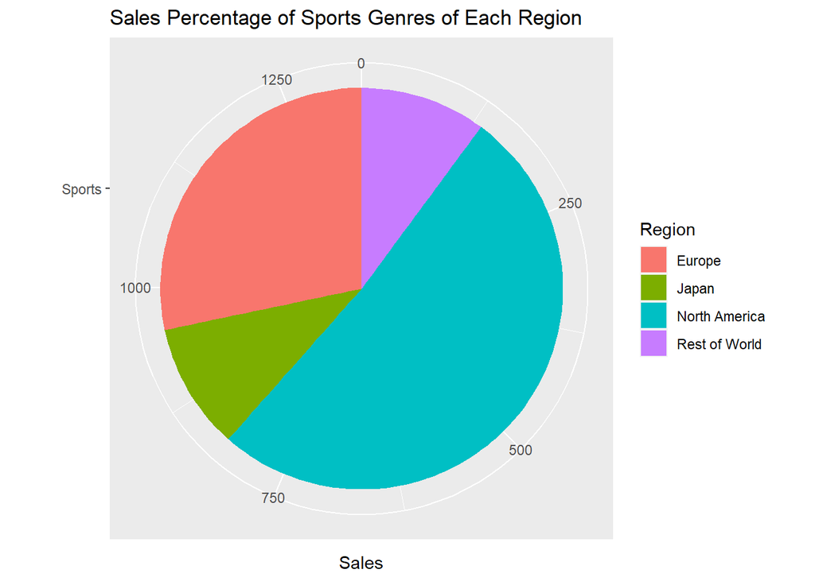

This pie chart displays the sales percentage of sports genres of each region labeled in the dataset. Each color in the chart represents a region. It is clear that North America has the most sales in sports video games, followed by Europe. Japan and rest of world have roughly identical sales. The chart demonstrates the distribution of sports video game sales worldwide.

## Chart 2

Here, we want to explore the sport game sales on different *platforms*. We build a column chart to show the sales.

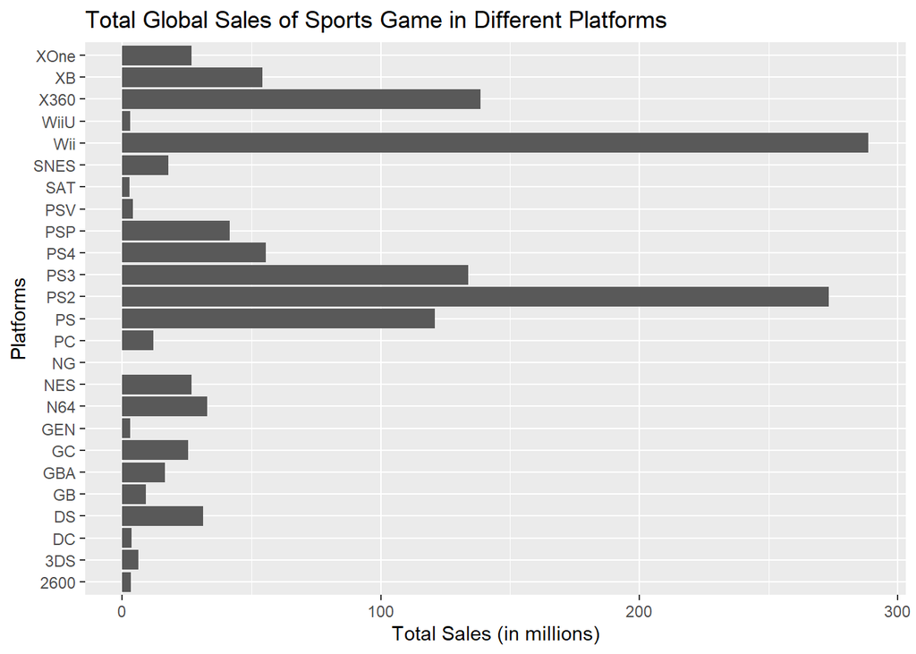

This column chart evals the relationship between platforms and sports game sales. According to this chart, with 288.61 million total sales, Wii is the highest selling platform for sports games. PS2 is the second-highest selling platform, with 273.41 million overall sales. The total game sales in both platforms take about 42.19 % of the sales in the overall platforms.

## Chart 3

The purpose we include this connected scatter chart because it helps us explore the relationship between the global Sports Game sales on December 22, 2016 and the *year of release*.

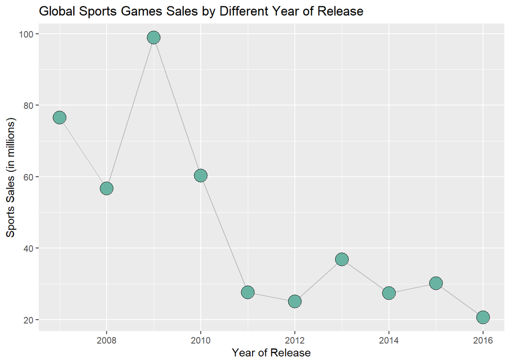